# Sentinel image segmentation using CNN (UNet encoder)

## Overview of Neural Network Architectures and Encoders

## Neural Network Architectures

There are four widely used types of neural network architectures, each suited to different types of data and tasks:

### 1. Feedforward Neural Networks (FNNs)

- **Structure**: Data flows in one direction—from input to output.
- **Use Cases**: Simple classification or regression (e.g., predicting house prices).
- **Limitation**: Cannot handle spatial or sequential relationships in the data.

### 2. Convolutional Neural Networks (CNNs)

- **Structure**: Uses convolutional layers with filters that scan across input (e.g., images).
- **Use Cases**: Image classification, object detection, medical imaging.
- **Key Feature**: Captures spatial patterns and hierarchies (edges, shapes).

### 3. Recurrent Neural Networks (RNNs)

- **Structure**: Designed for sequential data, with outputs feeding back into the network.
- **Use Cases**: Text generation, speech recognition, time series forecasting.
- **Limitation**: Struggles with long-term dependencies (addressed by LSTM/GRU variants).

### 4. Transformers

- **Structure**: Uses self-attention to process all elements of a sequence in parallel.
- **Use Cases**: Natural Language Processing (e.g., ChatGPT, translation, summarization).
- **Key Advantage**: Handles long-range dependencies and is highly parallelizable.

## Encoders in Neural Networks

An **encoder** is a component of a neural network that compresses input data (like text or images) into a smaller, informative representation called a **feature representation** or **embedding**.

### Types of Encoders

#### 1. Autoencoders

- **What**: Networks with two parts—an encoder compresses input, a decoder reconstructs it.
- **Use Case**: Dimensionality reduction, anomaly detection, denoising images.
- **Example**: Compressing a 28x28 image into a 10-dimensional latent vector.

#### 2. Transformer Encoders

- **What**: The encoder block of a Transformer model, which contextualizes inputs using self-attention.
- **Use Case**: Language models like BERT use transformer encoders for tasks like classification and entity recognition.
- **Key Feature**: Each word is represented based on its relation to all others in the sequence.

#### 3. Encoder-Decoder Models

- **What**: Two-part models where the encoder summarizes the input, and the decoder generates output.
- **Use Case**: Machine translation, summarization, image captioning.
- **Example**: Translating an English sentence into French.

## Summary Table

### Neural Network Architectures

| Architecture | Best For | Key Feature |
| --- | --- | --- |
| FNN | Basic tasks | Simple one-way data flow |
| CNN | Images | Spatial awareness via convolution |
| RNN | Sequential data | Temporal memory of past inputs |
| Transformer | Language tasks | Self-attention and parallel processing |

### Encoder Types

| Encoder Type | Role | Typical Use Case |
| --- | --- | --- |
| Autoencoder | Compress & reconstruct input | Denoising, anomaly detection |
| Transformer Encoder | Encode sequences contextually | Text classification, sentence embedding |
| Encoder-Decoder | Input → latent → output | Translation, summarization |

### Surface water mapping using Sentinel-2 imagery using U-NET CNN

```python
### Download and install geoai
### conda install -c conda-forge geoai
### Motivated by tutorial by Qiusheng Wu@creator of geoai
```

### Import libraries and data

```python
import geoai
import leafmap
```

```python
# check gpu status using pyTorch
import torch
if torch.cuda.is_available():
    print("GPU is available")
else:
    print("GPU is not available")
```

```
GPU is available
```

```python
url = "https://zenodo.org/records/5205674/files/dset-s2.zip?download=1"
data_dir = geoai.download_file(url)
```

```python
images_dir = f"{data_dir}/dset-s2/tra_scene"
masks_dir = f"{data_dir}/dset-s2/tra_truth"
tiles_dir = f"{data_dir}/dset-s2/tiles"
```

### Create training tiles

```python
# parameters for training files
geoai.export_geotiff_tiles_batch(
    images_folder = images_dir, # folder with input geotiff images
    masks_folder = masks_dir, # corresponding mask files
    output_folder = tiles_dir, # folder where tiles will be saved
    tile_size = 512, # patch size in pixels for training (higher more spatial context, but more memory)
    stride = 128, # overlap between patches, more training samples, and smoother predictions (less edge effects)
    quiet=True # suppress output messages
)

# After tiling, training batches will have shape:
# [batch_size, channels, height, width]
# For example: [32, 6, 512, 512]
# = 32 tiles per batch, 6 bands/channels (e.g., Sentinel-2), 512×512 pixels per tile
```

### Training semantic segmentation model

```python
geoai.train_segmentation_model(
    images_dir=f"{tiles_dir}/images", # folder with input geotiff images
    labels_dir=f"{tiles_dir}/masks", # corresponding mask files, each pixels = 0 or 1 (background or water)
    output_dir=f"{tiles_dir}/unet_models",
    architecture="unet", # model architecture, and parameters
    encoder_name="resnet34", # backbone encoder
    encoder_weights="imagenet",
    num_channels=6, # sentinel-2 has 6 bands
    num_classes=2,  # binary classification (water vs. non-water)
    batch_size=32, # 32 image/mask pairs per training batch
    num_epochs=20,  # run through the dataset 20 times (as a test)
    learning_rate=0.001, # standard learning rate for Adam or similar optimizers
    val_split=0.2, # 20% of data for validation
    verbose=True, # print training progress
)
```

### Evaluate model performance

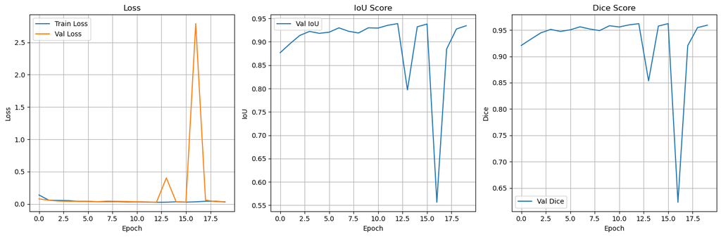

```
Best IoU: 0.9390
Final IoU: 0.9344
Best Dice: 0.9622
Final Dice: 0.9592
```

```python
geoai.plot_performance_metrics(
    history_path=f"{tiles_dir}/unet_models/training_history.pth",
    figsize=(15, 5),
    verbose=True,
)
```

### Run inference

```python
images_dir = f"{data_dir}/dset-s2/val_scene"
masks_dir = f"{data_dir}/dset-s2/val_truth"
predictions_dir = f"{data_dir}/dset-s2/predictions"
model_path = f"{tiles_dir}/unet_models/best_model.pth"
```

```python
geoai.semantic_segmentation_batch(
    input_dir=images_dir,
    output_dir=predictions_dir,
    model_path=model_path,
    architecture="unet",
    encoder_name="resnet34",
    num_channels=6,
    num_classes=2,
    window_size=512,
    overlap=256,
    batch_size=32,
    quiet=True,
)
```

```
WARNING:rasterio._env:CPLE_AppDefined in S2A_L2A_20190318_N0211_R061_6Bands_S2.tif: TIFFReadDirectory:Sum of Photometric type-related color channels and ExtraSamples doesn't match SamplesPerPixel. Defining non-color channels as ExtraSamples.
WARNING:rasterio._env:CPLE_AppDefined in TIFFReadDirectory:Sum of Photometric type-related color channels and ExtraSamples doesn't match SamplesPerPixel. Defining non-color channels as ExtraSamples.
```

```
Plot saved to: dset-s2/dset-s2/S2A_L2A_20190318_N0211_R061_6Bands_S2_comparison.png
```

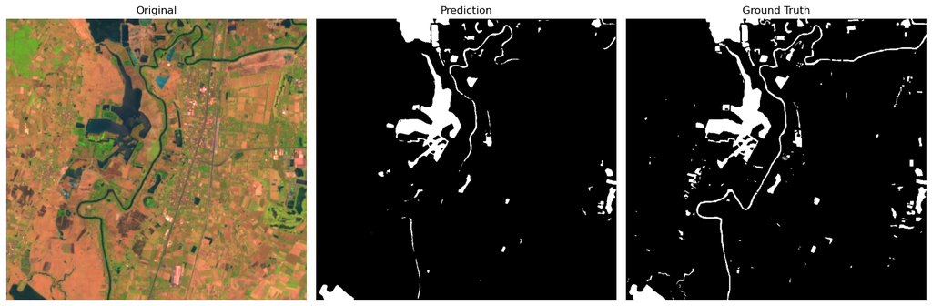

```python
test_image_path = (
    f"{data_dir}/dset-s2/val_scene/S2A_L2A_20190318_N0211_R061_6Bands_S2.tif"
)
ground_truth_path = (
    f"{data_dir}/dset-s2/val_truth/S2A_L2A_20190318_N0211_R061_S2_Truth.tif"
)
prediction_path = (
    f"{data_dir}/dset-s2/predictions/S2A_L2A_20190318_N0211_R061_6Bands_S2_mask.tif"
)
save_path = f"{data_dir}/dset-s2/S2A_L2A_20190318_N0211_R061_6Bands_S2_comparison.png"

fig = geoai.plot_prediction_comparison(
    original_image=test_image_path,
    prediction_image=prediction_path,
    ground_truth_image=ground_truth_path,
    titles=["Original", "Prediction", "Ground Truth"],
    figsize=(15, 5),
    save_path=save_path,
    show_plot=True,
    indexes=[5, 4, 3],
    divider=5000,
)
```

## Apply the pre-trained UNet model to other region

```python
url = "https://earth-search.aws.element84.com/v1/"
collection = "sentinel-2-l2a"
time_range = "2025-01-01/2025-07-20"
bbox = [128.6735, -16.2466, 128.9577, -16.0962]
```

```python
search = leafmap.stac_search(
    url=url,
    max_items=10,
    collections=[collection],
    bbox=bbox,
    datetime=time_range,
    query={"eo:cloud_cover": {"lt": 10}},
    sortby=[{"field": "properties.eo:cloud_cover", "direction": "asc"}],
    get_collection=True,
)
search
```

```python
bands = ["blue", "green", "red", "nir", "swir16", "swir22"]
assets = list(search.values())[0]
links = [assets[band] for band in bands]
for link in links:
    print(link)
```

```
https://sentinel-cogs.s3.us-west-2.amazonaws.com/sentinel-s2-l2a-cogs/52/L/DH/2025/6/S2B_52LDH_20250607_0_L2A/B02.tif
https://sentinel-cogs.s3.us-west-2.amazonaws.com/sentinel-s2-l2a-cogs/52/L/DH/2025/6/S2B_52LDH_20250607_0_L2A/B03.tif
https://sentinel-cogs.s3.us-west-2.amazonaws.com/sentinel-s2-l2a-cogs/52/L/DH/2025/6/S2B_52LDH_20250607_0_L2A/B04.tif
https://sentinel-cogs.s3.us-west-2.amazonaws.com/sentinel-s2-l2a-cogs/52/L/DH/2025/6/S2B_52LDH_20250607_0_L2A/B08.tif
https://sentinel-cogs.s3.us-west-2.amazonaws.com/sentinel-s2-l2a-cogs/52/L/DH/2025/6/S2B_52LDH_20250607_0_L2A/B11.tif
https://sentinel-cogs.s3.us-west-2.amazonaws.com/sentinel-s2-l2a-cogs/52/L/DH/2025/6/S2B_52LDH_20250607_0_L2A/B12.tif
```

```python
out_dir = "s2"
leafmap.download_files(links, out_dir)
```

```python
s2_path = "s2.tif"
geoai.stack_bands(input_files=out_dir, output_file=s2_path)
```

```python
s2_mask = "s2_mask.tif"
model_path = f"{tiles_dir}/unet_models/best_model.pth"
```

```python
geoai.semantic_segmentation(
    input_path=s2_path, # path to the input Sentinel-2 image
    output_path=s2_mask, # path where the mask will be saved
    model_path=model_path, # path to the trained model
    architecture="unet", # model architecture
    encoder_name="resnet34", # pre-trained encoder
    num_channels=6,# Sentinel-2 has 6 bands
    num_classes=2, # binary classification (water vs. non-water)
    window_size=512, # tile size for sliding window
    overlap=256, # overlap between tiles for smooth edge artifacts
    batch_size=32, # number of tiles to process in parallel
)
```

### Visualise the results

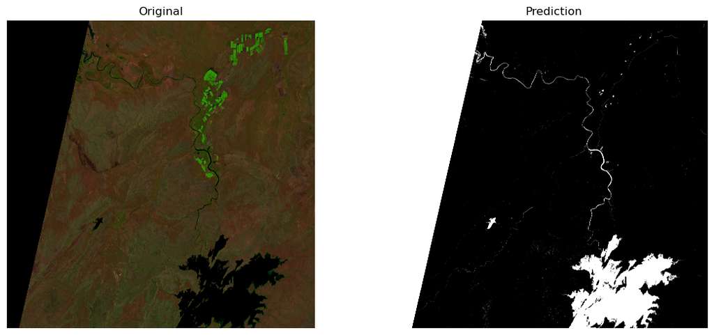

```python
fig = geoai.plot_prediction_comparison(
    original_image=s2_path,         # sentinel-2 RGB/NIR image
    prediction_image=s2_mask,       # predicted mask from segmentation
    ground_truth_image=None,        # no ground truth
    titles=["Original", "Prediction"],
    figsize=(12, 5),
    show_plot=True,
    indexes=[5, 4, 3],              # B6-B5-B4 or B4-B3-B2 RGB bands, adjust as needed
    divider=10000                   # for Sentinel-2, divides 0–10000 reflectance values to [0–1]
)
```